# Measuring bat CF calls - a demo

This notebook has all the code and prototyping functions required to measure various aspects of a single horseshoe bat call automatically.

Last updated 2020-02-09

```python
from datetime import datetime
import matplotlib.pyplot as plt
plt.rcParams['agg.path.chunksize']
import numpy as np
import pandas as pd
from peakutils import peak
import scipy.signal as signal
import soundfile as sf
```

```python
%matplotlib notebook
```

```python
def dB(X):
    return 20*np.log10(X)

def rms(X):
    return np.sqrt(np.mean(X**2.0))

def calc_energy(X):
    return np.sum(X**2.0)

def get_power_spectrum(audio, fs=250000.0):
    spectrum = np.fft.rfft(audio)
    freqs = np.fft.rfftfreq(audio.size, 1.0/fs)
    return dB(abs(spectrum)), freqs


def get_robust_peak_frequency(audio, **kwargs):
    '''Makes a spectrogram from the audio
    and calcualtes the peak frequency by averaging
    each slice of the spectrogram's FFT's.

    This 'smooths' out the structure of the power
    spectrum and allows a single and clear peak
    detection.

    Thanks to Holger Goerlitz for the suggestion.

    Parameters
    ----------

    Keyword Arguments
    ------------------
    fs

    NFFT

    noverlap


    Returns
    --------



    '''
    seg_length = kwargs.get('seg_length',256)
    frequency,t,sxx = signal.spectrogram(audio, fs=int(kwargs['fs']), nperseg=seg_length, noverlap=seg_length-1)
    averaged_spectrogram = np.apply_along_axis(np.sum, 1, sxx)
    peak = np.argmax(averaged_spectrogram)
    peak_frequency = frequency[peak]
    return peak_frequency

def remove_frequency(audio, target_frequency, **kwargs):
    '''
    Parameters
    -----------
    audio : np.array

    target_frequency : float>0
          Frequency component to be filtered out from audio in Hz.

    fs : float>0
          Sampling frequency in Hz.

    Keyword Arguments
    ----------------
    q_factor : float >0
              q_factor of the notch filter. See signal.iirnotch for more details.
              Defaults to 1.

    Returns
    ----------
    filtered_audio : np.array


    Notes
    ------
    It may seem like setting a higher q_factor is better to remove the Cf. This is not true in
    my experience. A higher q-factor leads to a very narrow filtering, which can leave a lot of
    energy remaining in the CF part - even though the target_frequency per se is filtered out.

    To effectively remove the CF part of a call lower may be better!
    '''
    nyquist = kwargs['fs']*0.5
    q_factor = kwargs.get('q_factor',1)
    b,a = signal.iirnotch(target_frequency/nyquist,q_factor)

    filtered_audio = signal.lfilter(b,a,audio)
    return filtered_audio


def get_peak_frequency(audio, fs=250000):
    '''
    '''
    spectrum = np.fft.rfft(audio)
    freqs = np.fft.rfftfreq(audio.size, 1.0/fs)
    peak_freq = freqs[np.argmax(spectrum)]
    return peak_freq

def measure_CF_rms(audio, peak_CF,
                           **kwargs):
    '''
    Measures the CF rms after high pass filtering

    Parameters
    ---------
    audio : np.array

    peak_CF : float>0
              Peak frequency in Hz. The highpass filter will have its cutoff point at this frequency.

    Keyword Arguments
    ------------------
    fs : sampling rate in Hz.
         Defaults to 250kHz

    Returns
    --------
    CF_rms : float>0
             RMS of the highpassed audio segment


    '''
    fs = kwargs.get('fs', 250000.0)
    b,a = signal.butter(4, peak_CF/fs,'highpass')
    hp_audio = signal.filtfilt(b,a,audio)
    CF_rms = rms(hp_audio)
    return CF_rms


def measure_FM_rms(audio, peak_CF,
                           **kwargs):
    '''
    Measures the CF rms after high pass filtering

    Parameters
    ---------
    audio : np.array

    peak_CF : float>0
              Peak frequency in Hz. The highpass filter will have its cutoff point at this frequency.

    Keyword Arguments
    ------------------
    fs : sampling rate in Hz.
         Defaults to 250kHz

    Returns
    --------
    CF_rms : float>0
             RMS of the highpassed audio segment


    '''
    fs = kwargs.get('fs', 250000.0)
    b,a = signal.butter(4, peak_CF/fs, 'lowpass')
    lp_audio = signal.filtfilt(b,a,audio)
    CF_rms = rms(lp_audio)
    return CF_rms

def calc_sound_borders(audio, percentile=99):
    '''Gives the start and stop of a sound based on the percentile
    cumulative energy values.

    Returns
    --------
    start, end : int.
    '''
    audio_sq = audio**2.0
    cum_energy = np.cumsum(audio_sq)
    outside_percentile = (100-percentile)*0.5
    lower, higher = outside_percentile, 100-outside_percentile
    start, end = np.percentile(cum_energy,[lower, higher])
    start_ind = np.argmin(abs(cum_energy-start))
    end_ind = np.argmin(abs(cum_energy-end))
    return start_ind, end_ind
```

```python
# check raw audo
rec, fs = sf.read('example_audio/T0000568.WAV')
start, stop = 57.683, 57.708
channel = 1
part = rec[int(start*fs):int(stop*fs),channel]
b,a = signal.butter(4,np.array([70000, 115000])/(fs*0.5), 'bandpass')
part = signal.filtfilt(b,a,part)
```

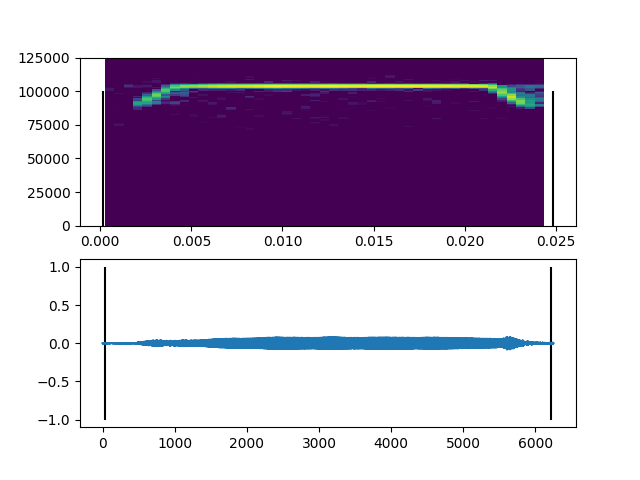

```python
start, end = calc_sound_borders(part)
plt.figure()
plt.subplot(211)
plt.specgram(part, Fs=fs, NFFT=256, vmin=dB(np.max(part))-80);
plt.vlines(start/250000.0, 0, 100000)
plt.vlines(end/250000.0, 0, 100000)
plt.subplot(212)
plt.plot(part)
plt.vlines(start, -1,1 )
plt.vlines(end, -1,1)
```

```python
def limit_to_dynamic_range(dB_specgram, **kwargs):
    dynamic_range = kwargs.get('dynamic_range', 80)
    range_value = np.max(dB_specgram) - dynamic_range

    above_dynamic_range = np.argwhere(dB_specgram>=range_value)
    all_above = np.ones(dB_specgram.shape)*-999

    for each in above_dynamic_range:
        all_above[each[0], each[1]] = dB_specgram[each[0], each[1]]

    return all_above


def get_peak_frequencies(audio, **kwargs):
    '''
    '''
    seg_length = kwargs.get('seg_length',128)
    f,t, specgram = signal.spectrogram(audio, fs=kwargs.get('fs',1),
                                       nperseg=seg_length, noverlap=seg_length-1)
    dB_specgram = dB(specgram)
    limited_dynamic_range = limit_to_dynamic_range(dB_specgram.copy(), **kwargs)
    max_rows = np.apply_along_axis(np.argmax,0, limited_dynamic_range)
    peak_freqs = [f[each] for each in max_rows]
    return np.array(peak_freqs), limited_dynamic_range, dB_specgram
```

```python
seglen = 128
peak_freqs, ld, dbs = get_peak_frequencies(part, dynamic_range=70, seg_length=seglen, fs=250000)
```

higher = np.argwhere(dbs>=np.max(dbs)-80) cy = np.ones(dbs.shape)*-999 for each in higher: cy[each[0], each[1]] = dbs[each[0], each[1]]

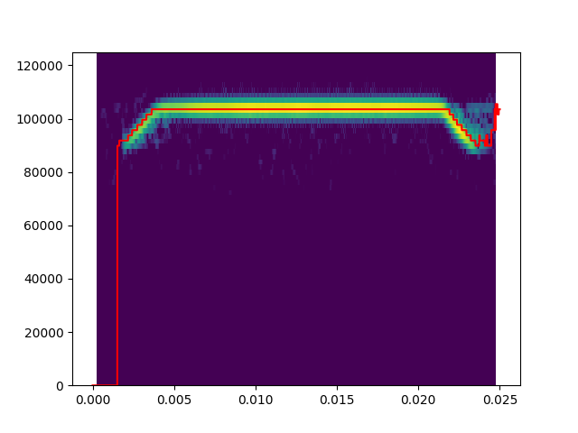

```python
plt.figure()
plt.specgram(part, Fs=fs, NFFT=seglen, noverlap=seglen-1, vmin=dB(np.max(part))-80);
plt.plot(np.linspace(0,part.size/250000.0,peak_freqs.size),peak_freqs,'r')
```

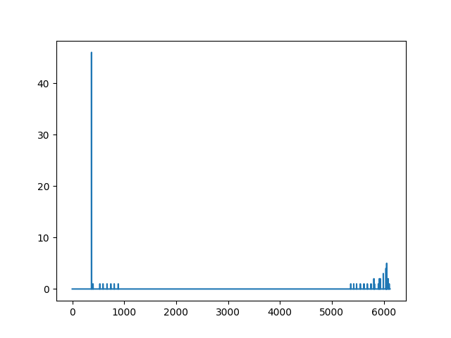

```python
plt.figure()
plt.plot(abs(np.diff(peak_freqs)/(fs/seglen)))
```

```python
def bandpass_around_peak(audio, fs=250000, bandwidth=10000):
    '''
    '''
    peak_freq = get_peak_frequency(audio, fs)
    print(peak_freq)
    low_high = np.array([-0.5*bandwidth, +0.5*bandwidth])+peak_freq
    nyquist = fs*0.5
    b,a = signal.butter(4, low_high/nyquist,'bandpass')

    bp_audio = signal.lfilter(b,a,audio)
    return(bp_audio)
```

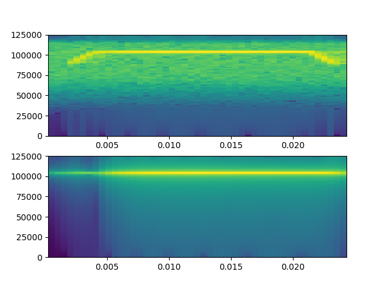

```
104360.0
```

```python
plt.figure()
plt.subplot(211)
plt.specgram(part, Fs=fs);
plt.subplot(212)
plt.specgram(bandpass_around_peak(part, bandwidth=500), Fs=fs);
```

```python
cf_part = bandpass_around_peak(part, bandwidth=10000)
dB(rms(cf_part)), dB(rms(part))
```

```
104360.0
```

```
(-28.109674405051884, -27.8372269042644)
```

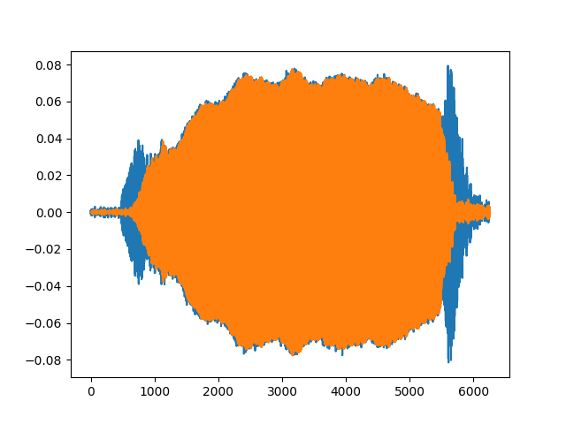

```python
plt.figure()
plt.plot(part)
plt.plot(cf_part)
```

```python
cfpart_sp = get_power_spectrum(cf_part)
part_sp = get_power_spectrum(part)
```

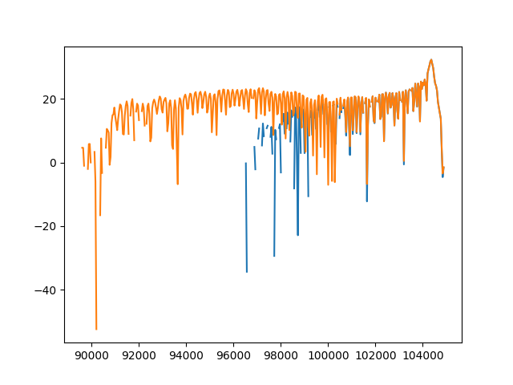

```python
plt.figure()
plt.plot(cfpart_sp[1], dB(cfpart_sp[0]))
plt.plot(part_sp[1], dB(part_sp[0]))
```

```python
q = np.random.normal(0,0.5,int(fs))
peak_freq = 100000.0
print(peak_freq)
bandwidth = 05000.0
low_high = np.array([-0.5*bandwidth, +0.5*bandwidth])+peak_freq
nyquist = fs*0.5
b,a = signal.butter(2, low_high/nyquist,'band')
bp_q = signal.lfilter(b,a,q)
```

```
100000.0
```

```python
q_sp = get_power_spectrum(q)
bpq_sp = get_power_spectrum(bp_q)
```

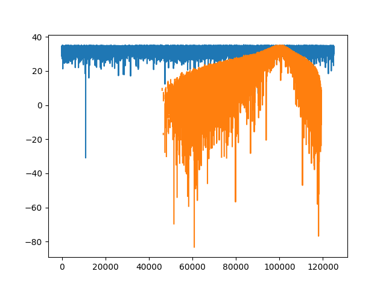

```python
plt.figure()
plt.plot(q_sp[1], dB(q_sp[0]))
plt.plot(bpq_sp[1], dB(bpq_sp[0]))
```

### To actually test any kind of method, we first need some kind of synthetic data. The function below allows us to create artifical calls with known start and end times of our CF calls. This will tell us if our methods actuall work.

```python
## from the make_CF_training_data module
def make_one_CFcall(call_durn, fm_durn, cf_freq, fs, call_shape):
    '''

    TODO : make harmonics
    '''
    # choose an Fm start/end fr equency :
    FM_bandwidth= xrange(5,25)
    fm_bw = np.random.choice(FM_bandwidth, 1)*10.0**3
    print(fm_bw)
    start_f = cf_freq - fm_bw
    #
    polynomial_num = 25
    t = np.linspace(0, call_durn, int(call_durn*fs))
    # define the transition points in the staplepin
    freqs = np.tile(cf_freq, t.size)
    numfm_samples = int(fs*fm_durn)
    if call_shape == 'staplepin':
        freqs[:numfm_samples] = np.linspace(start_f,cf_freq,numfm_samples, endpoint=True)
        freqs[-numfm_samples:] = np.linspace(cf_freq,start_f,numfm_samples, endpoint=True)
        p = np.polyfit(t, freqs, polynomial_num)

    elif call_shape == 'rightangle':
        # alternate between rising and falling right angle shapes
        rightangle_type = np.random.choice(['rising','falling'],1)
        if rightangle_type == 'rising':
            freqs[:numfm_samples] = np.linspace(cf_freq,start_f,numfm_samples, endpoint=True)
        elif rightangle_type == 'falling':
            freqs[-numfm_samples:] = np.linspace(cf_freq,start_f,numfm_samples, endpoint=True)
        p = np.polyfit(t, freqs, polynomial_num)

    else:
        raise ValueError('Wrong input given')

    cfcall = signal.sweep_poly(t, p)

    #windowing = np.random.choice(['hann', 'nuttall', 'bartlett','boxcar'], 1)[0]
    windowing= 'boxcar'
    cfcall *= signal.get_window(windowing, cfcall.size)
    return(cfcall)
```

```python
cfcall_nonoise = make_one_CFcall(0.050, 0.005, 100000, 250000, 'staplepin')
cfcall = np.random.normal(0,10**(-40/20),cfcall_nonoise.size+int(fs*0.010))
call_start = 250
cfcall[call_start:cfcall_nonoise.size+call_start] += cfcall_nonoise
```

```
[8000.]
```

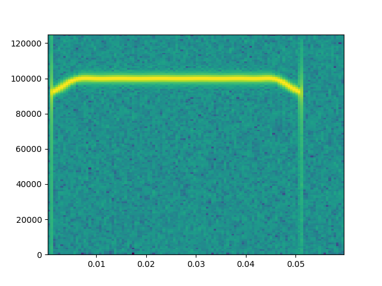

```python
plt.figure()
plt.specgram(cfcall, Fs=fs);
```

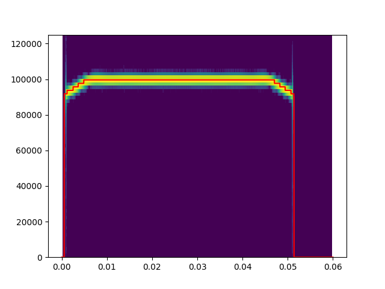

```python
seglen=128
peak_freqs, ld, dbs = get_peak_frequencies(cfcall, dynamic_range=50, seg_length=seglen, fs=250000)

plt.figure()

plt.specgram(cfcall, Fs=fs, NFFT=seglen, noverlap=seglen-1, vmin=dB(np.max(cfcall))-80);
plt.plot(np.linspace(0,cfcall.size/250000.0,peak_freqs.size),peak_freqs,'r')
```

```python
peak_freq = 100*10**3
bandwidth = 20000
print(peak_freq)
low_high = np.array([-0.5*bandwidth, +0.5*bandwidth])+peak_freq
nyquist = fs*0.5
b,a = signal.butter(2, low_high/nyquist,'bandpass')
w,h = signal.freqs(b,a)

cfcall_filter = signal.lfilter(b,a,cfcall)
```

```
100000
```

```python
# notch filtering
b,a = signal.iirnotch((peak_freq)/nyquist, 25)
cfcall_notch = signal.lfilter(b,a, cfcall)
```

```python
18000.0/40000.0
```

```
0.45
```

```python
dB(rms(cfcall[12000:])), dB(rms(cfcall_notch[11523:12787]))
```

```
(-9.026082179811155, -4.924793467788588)
```

```python
dB(rms(cfcall)), dB(rms(cfcall_filter)), dB(rms(cfcall_notch))
```

```
(-3.800834292286704, -3.8978125668000256, -12.619732948429283)
```

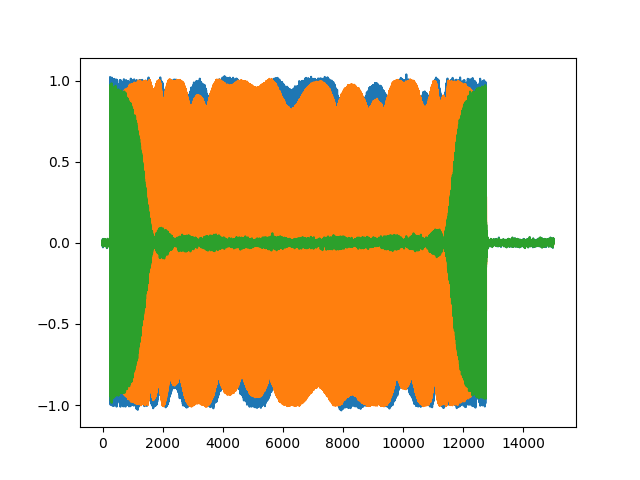

```python
plt.figure()
plt.plot(cfcall)
plt.plot(cfcall_filter)
plt.plot(cfcall_notch)
```

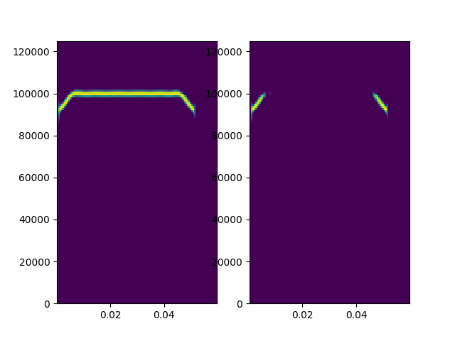

```python
specgram_dyn_range = 20*np.log10(np.max(abs(cfcall)))-60
plt.figure()
plt.subplot(121)
plt.specgram(cfcall, Fs=fs, vmin=specgram_dyn_range);
plt.subplot(122)
plt.specgram(cfcall_notch, Fs=fs, vmin=specgram_dyn_range);
```

```python
peak_part = get_peak_frequency(part)
# notch filtering
b,a = signal.iirnotch((peak_part)/nyquist, 25)
part_notch = signal.lfilter(b,a, part)
peak_part
```

```
104360.0
```

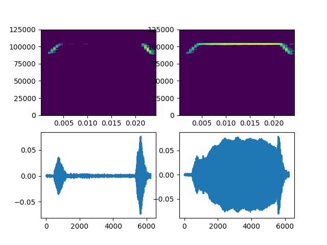

```python
specgram_dyn_range = 20*np.log10(np.max(abs(cfcall)))-90

plt.figure()
plt.subplot(221)
plt.specgram(part_notch, Fs=fs, NFFT=256, vmin=specgram_dyn_range);
plt.subplot(223)
plt.plot(part_notch);
plt.subplot(222)
plt.specgram(part, Fs=fs, NFFT=256, vmin=specgram_dyn_range);
plt.subplot(224)
plt.plot(part);
```

### Designing an automated CF and FM portion identifier:

The basic idea Holger and I discussed was basically to first apply a notch filter. Then use a peak detection algorithm to identify the left-over FM audio bumps. There cannot be more than 2 bumps or zero bumps - and so on.

Holger also suggested to use a 'mean' spectrum created by averaging out each vertical slice of a spectrogram - as it is less sensitive to the very fine structure (and multiple peaks) in a whole-audio FFT.

```python
def moving_rms(X, **kwargs):
    '''Calculates moving rms of a signal with given window size.
    Outputs np.array of *same* size as X. The rms of the
    last few samples <= window_size away from the end are assigned
    to last full-window rms calculated

    Parameters
    ----------
    X :  np.array of Nsample values

    Keyword Arguments
    -----------------
    window_size : int>0
                 Defaults to 125 samples.


    Returns
    -------
    all_rms : np.array of Nsamples values.

    '''
    window_size = kwargs.get('window_size', 125)
    starts = np.arange(0, X.size)
    stops = starts+window_size
    valid = stops<X.size
    valid_starts = np.int32(starts[valid])
    valid_stops = np.int32(stops[valid])
    all_rms = np.ones(X.size).reshape(-1,1)

    for i, (start, stop) in enumerate(zip(valid_starts, valid_stops)):
        rms_value = rms(X[start:stop])
        all_rms[i] = rms_value

    # replace all un-assigned samples with the last rms value
    all_rms[all_rms==1] = rms_value

    return all_rms

def segment_sound_from_background(audio, **kwargs):
    '''Selects the sound from an audio clip when the majority of the
    clip is background, and the sound of interest only ocuppies a small
    region of it.

    Here a 95% energy window (as used in calc_sound_borders) will fail as it will lead
    to extremely generous start-stop windows - and include a lot of the background.

    The moving dB rms of the audio clip is calcualted and portions of the audio clip
    with above threshold dB rms are considered the signal.

    Keyword Arguments
    -------------------
    window_size : int>0
                Window size for moving rms calcualtions.
                Defaults to 125 samples.

    background_percentile: 100 > float > 0
                How much of the audio is generally expected to


    Returns
    ----------



    '''
    signal_moving_rms = moving_rms(audio, **kwargs)

    moving_dBrms = np.around(dB(signal_moving_rms))
    moving_dBrms -= np.max(moving_dBrms)

    background_percentile = kwargs.get('background_percentile', 50)
    threshold = np.percentile(moving_dBrms.flatten(), background_percentile) + 3

    try:
        above_threshold = np.where(moving_dBrms>threshold)[0]
        start, stop = np.min(above_threshold), np.max(above_threshold)
        return start, stop
    except:
        raise FMIdentificationError('There is not enough background in the audio clip. Please check if \
        the whole audio has signal!,or reduce the background_percentile  from current value.')


def measure_hbc_call(audio, **kwargs):
    '''

    Parameters
    ----------
    audio : np.array

    fs : float>0.
         sampling rate in Hz.

    Returns
    --------

    measurements : pd.DataFrame with the following columns and entries
        call_duration : float>0
                        The duration of the entire call

        call_energy : float>0
                    Eenrgy in the whole call.


        FM_energy : float>0
                    The energy of the FM portion/s. This is the energy in the call
                    post CF removal.

        CF_energy : float>0
                    Energy in the CF component. This is calculated by subtracting the
                    whole calls energy from the energy remaining post CF removal.

        CF_duration : float>0
                      Duration of whole call in seconds.

        FM_duration : array, list-like
                      Duration of the FM portions. if there are up and down FM sweeps, then
                      two values are returned.


        peak_CF : float>0
                  The peak CF in Hz

        FM_terminal_-10dB : float>0
                        The terminal frequency of the FM. The Cf component of a call
                        is notch filtered out, and the FM part/s are left. The
                        FM parts are then isolated and their power spectrum is calculated.
                        The terminal frequency is the lowest frequency that is -10dB
                        from the peak of the power spectrum.

        FM_times : nFM x 2 np.array
                    Start and end times for the detected FM sweep/s.
                    One row is one FM sweep.

        CF_times : 1x2 np.array
                   1 entry with start and end time.

    sound_segments :
        call : np.array.
               A slightly narrower selection of the audio with 99% of the audio's energy
               in it.

        nocf_call : np.array.
                The call without the CF segment in it.

        fm_segments: np.array
                One or two extracted FM segments.


    '''
    # narrow down the audio clip even more to extract exactly the sound
    call_window = calc_sound_borders(audio, 95)
    call = audio[call_window[0]:call_window[1]]

    # call duration of the entire call
    call_duration = call.size/float(fs)
    #energy of the entire call
    call_energy = calc_energy(call)

    #identify peak frequency
    peak_frequency = get_robust_peak_frequency(call, **kwargs)

    #get rid of peak frequency
    call_no_CF = remove_frequency(call, peak_frequency, **kwargs)

    # calculate energy of CF
    non_cf_energy = calc_energy(call_no_CF)
    CF_energy = call_energy - non_cf_energy

    # extract FM sections and measure things about them
    fm_segments, fm_times = identify_FM(call_no_CF, **kwargs)
    fm_terminal_freqs = [get_terminal_frequency(eachfm, **kwargs) for eachfm in fm_segments]
    fm_energy = [ calc_energy(eachfm) for eachfm in fm_segments]

    measurements = assemble_all_measurements(call_duration, call_energy, CF_energy, fm_energy,
                                             peak_frequency, fm_times, fm_terminal_freqs, **kwargs)

    sound_segments = assemble_all_sound_segments(call, call_no_CF, fm_segments)

    return sound_segments, measurements

def assemble_all_measurements(call_duration, call_energy, CF_energy, fm_energy,
                                             peak_frequency, fm_times, fm_terminal_freqs, **kwargs):
    '''
    '''
    msmts = {'call_duration':[call_duration],
            'call_energy':[call_energy],
            'cf_energy':[CF_energy],
            'peak_frequency':[peak_frequency],
            }
    print(fm_times)
    for fm_time, fm_tf, fm_engy in zip(fm_times, fm_terminal_freqs, fm_energy):
        print fm_time
        start_of_fm = fm_time[0]/float(kwargs['fs'])
        end_of_fm = fm_time[1]/float(kwargs['fs'])

        if  end_of_fm <= call_duration*0.5:
            fm_type = 'upfm_'
        elif end_of_fm > call_duration*0.5:
            fm_type = 'downfm_'

        msmts[fm_type+'energy'] = [fm_engy]
        msmts[fm_type+'terminal_frequency'] = [fm_tf]
        msmts[fm_type+'start_time'] = [start_of_fm]
        msmts[fm_type+'end_time'] = [end_of_fm]

    measurements = pd.DataFrame(data=msmts)
    return measurements


def assemble_all_sound_segments(call, nocf, fm_segments):
    '''
    '''
    all_sounds = [call, nocf]
    for eachfm in fm_segments:
        all_sounds.append(eachfm)
    return all_sounds


def identify_FM(no_CF_call, **kwargs):
    '''

    Keyword Arguments
    -------------------
    fs
    fm_energy_percentile
    smoothing_durn
    min_cf_duration
    relative_threshold
    fm_max_durn
    '''
    fs = kwargs['fs']
    fm_energy_percentile = kwargs.get('fm_energy_percentile', 95)
    smoothing_length = int(kwargs.get('smoothing_durn', 0.002)*fs)
    smoothed_nocf = np.convolve(abs(no_CF_call), np.ones(smoothing_length),'same')

    min_cf_duration = kwargs.get('min_cf_duration', 0.01)
    relative_threshold = kwargs.get('relative_threshold', 0.5)
    peaks = peak.indexes(smoothed_nocf,thres=relative_threshold, min_dist=int(min_cf_duration*fs))

    if len(peaks)>2:
        print(peaks)
        raise FMIdentificationError('Too many FM peaks detected')

    fm_max_durn = kwargs.get('fm_max_durn', 0.005)
    half_fm_samples = int(fm_max_durn*0.5*fs)

    fm_segments = []
    fm_times =[]
    for each_peak in peaks:
        broad_fm_section, audio_startstop = take_segment_around_peak(no_CF_call, each_peak, half_fm_samples)
        fm_start,fm_stop = segment_sound_from_background(broad_fm_section,**kwargs)
        fm = broad_fm_section[fm_start:fm_stop]
        fm_segments.append(fm)
        start_stop = [fm_start + audio_startstop[0], fm_start + audio_startstop[0] + fm.size]
        fm_times.append(start_stop)
    return fm_segments, fm_times


def take_segment_around_peak(audio, peak, samples_LR_of_peak):
    '''
    '''
    start = peak-samples_LR_of_peak
    stop = peak+samples_LR_of_peak

    if start <0:
        start = 0

    if stop > audio.size:
        stop = audio.size-1

    segment_around_peak = audio[start:stop]
    return segment_around_peak, [start,stop]

def get_terminal_frequency(audio, **kwargs):
    '''Gives the -XdB frequency from the peak.

    The power spectrum is calculated and smoothened over 3 frequency bands to remove
    complex comb-like structures.

    Then the lowest frequency below XdB from the peak is returned.

    Parameters
    ----------
    audio : np.array

    Keyword Arguments
    --------------------

    fs : float>0
        Sampling rate in Hz

    threshold : float < 0
        The terminal frequency is calculated based on finding the level of the peak frequency
        and choosing the lowest frequency which is -10 dB (20log10) below the peak level.
        Defaults to -10 dB

    Returns
    ---------
    terminal_frequency


    '''

    threshold = kwargs.get('threshold', -10)

    power_spectrum, freqs,  = get_power_spectrum(audio, kwargs['fs'])
    # smooth the power spectrum over 3 frequency bands to remove 'comb'-iness in the spectrum
    smooth_spectrum = np.convolve(10**(power_spectrum/20.0), np.ones(3)/3,'same')
    smooth_power_spectrum = dB(abs(smooth_spectrum))

    peak = np.max(smooth_power_spectrum)
    geq_threshold = smooth_power_spectrum >= peak + threshold
    all_frequencies_above_threshold = freqs[geq_threshold]

    terminal_frequency = np.min(all_frequencies_above_threshold)
    return terminal_frequency



class FMIdentificationError(ValueError):
    pass
```

```python
sounds, msmts = measure_hbc_call(part, fs=250000, min_cf_duration=0.01, q_factor=3, relative_threshold=0.4)
```

```
[[234, 776], [5248, 5670]]
[234, 776]
[5248, 5670]
```

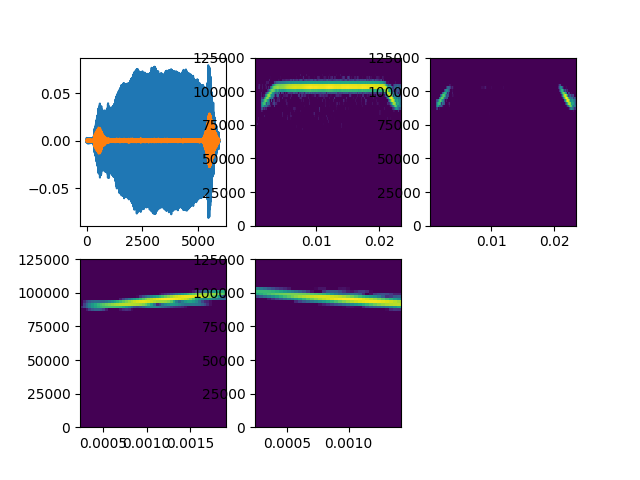

```python
dyn_vmin = 20*np.log10(np.max(abs(sounds[0]))) - 80
plt.figure()
plt.subplot(231)
plt.plot(sounds[0], label='whole call')
plt.plot(sounds[1], label='only FM')
plt.subplot(232)
plt.specgram(sounds[0], Fs=fs, NFFT=128, noverlap=120, vmin=dyn_vmin);
plt.subplot(233)
plt.specgram(sounds[1], Fs=fs, NFFT=128, noverlap=120, vmin=dyn_vmin);
plt.subplot(234)
plt.specgram(sounds[2], Fs=fs, NFFT=128, noverlap=120, vmin=dyn_vmin);
try:
    plt.subplot(235)
    plt.specgram(sounds[3], Fs=fs, NFFT=128, noverlap=120, vmin=dyn_vmin);
except:
    pass
```

```python
anotation_audio_folder = '/media/tbeleyur/THEJASVI_DATA_BACKUP_3/aditya_34am_20180817/real_names/'

good_calls = pd.read_csv('Manual audio annotation.csv')
good_calls.head()
```

|  | audio_annotation_file | start_random_point | search_start_time(s) | No._of_ms_whole_screen | call_start_time | call_end_time | SNR(dB RMS) | Comments | call_dBrms | cf_start_time | cf_end_time | cf_dbrms | fm1_start_time | fm1_end_time | fm1_dbrms | fm2_start_time | fm2_end_time | fm2_dbrms |
| --- | --- | --- | --- | --- | --- | --- | --- | --- | --- | --- | --- | --- | --- | --- | --- | --- | --- | --- |
| 0 | matching_annotaudio_Aditya_2018-08-17_34_1 | 53 | 1.272 | 75 | 1.279 | 1.291 | 20.76 | There are some echoes present towards the end | NaN | NaN | NaN | NaN | NaN | NaN | NaN | NaN | NaN | NaN |
| 1 | matching_annotaudio_Aditya_2018-08-17_34_2 | 11 | 0.101 | 55 | 0.022 | 0.042 | 23.65 | NaN | NaN | NaN | NaN | NaN | NaN | NaN | NaN | NaN | NaN | NaN |
| 2 | matching_annotaudio_Aditya_2018-08-17_34_3 | 17 | 0.047 | 70 | 0.117 | 0.140 | 28.55 | Silent interval chosen from 2018-08-17_34 | NaN | NaN | NaN | NaN | NaN | NaN | NaN | NaN | NaN | NaN |
| 3 | matching_annotaudio_Aditya_2018-08-17_34_4 | 93 | 0.595 | 80 | 0.027 | 0.047 | 26.88 | Not very clean. There is some overlap just bef... | NaN | NaN | NaN | NaN | NaN | NaN | NaN | NaN | NaN | NaN |
| 4 | matching_annotaudio_Aditya_2018-08-17_34_7 | 12 | 0.149 | 80 | 0.237 | 0.259 | 22.73 | NaN | NaN | NaN | NaN | NaN | NaN | NaN | NaN | NaN | NaN | NaN |

```python
msmts
```

|  | call_duration | call_energy | cf_energy | downfm_end_time | downfm_energy | downfm_start_time | downfm_terminal_frequency | peak_frequency | upfm_end_time | upfm_energy | upfm_start_time | upfm_terminal_frequency |
| --- | --- | --- | --- | --- | --- | --- | --- | --- | --- | --- | --- | --- |
| 0 | 0.023748 | 10.282535 | 10.179055 | 0.02268 | 0.077626 | 0.020992 | 90639.810427 | 104492.1875 | 0.003104 | 0.017865 | 0.000936 | 90405.904059 |

```python
def make_overview_figure(audio, sounds, msmts, **kwargs):
    '''
    '''

    fftsize = kwargs.get('fftsize', 128)
    dyn_range = kwargs.get('dyn_range', 80)


    dyn_vmin = 20*np.log10(np.max(abs(sounds[0]))) - dyn_range

    plt.figure(figsize=(8,7))
    a0 = plt.subplot(231)
    plt.title('Oscillogram')
    plt.plot(sounds[0], label='whole call')
    plt.plot(sounds[1], label='non CF')
    plt.legend()
    plt.subplot(232)
    plt.title('Manual selection')
    plt.specgram(one_call, Fs=fs, NFFT=fftsize, noverlap=fftsize-1, vmin=dyn_vmin);
    plt.yticks([])
    plt.subplot(233)
    plt.title('Fine selection of call')
    plt.specgram(sounds[0], Fs=fs, NFFT=fftsize, noverlap=fftsize-1, vmin=dyn_vmin);
    plt.tick_params(axis='y', which='both', labelleft='off', labelright='on')
    # show CF peak frequency
    plt.hlines(msmts['peak_frequency'],0,sounds[0].size/float(fs), 'k',
               linewidth=2.0)
    # show FM sections along with the terminal frequencies
    for fm_start, fm_end in [ ('downfm_start_time', 'downfm_end_time'), ('upfm_start_time','upfm_end_time')]:
        try:
            plt.vlines([msmts[fm_start],msmts[fm_end]], 50000, fs*0.5,'r' )
            terminal_frequency = fm_start.split('_')[0]+'_terminal_frequency'
            plt.hlines(msmts[terminal_frequency],msmts[fm_start],msmts[fm_end],'r')

        except:
            pass

    plt.subplot(234)
    plt.title('Non-CF call')
    plt.specgram(sounds[1], Fs=fs, NFFT=fftsize, noverlap=fftsize-1, vmin=dyn_vmin);
    plt.subplot(235)
    plt.title('First FM')
    # plot FM with 0.5*fftsize
    half_winsize = int(fftsize*0.5)
    plt.specgram(sounds[2], Fs=fs, NFFT=half_winsize, noverlap=half_winsize-1, vmin=dyn_vmin);
    plt.yticks([])

    try:
        plt.subplot(236)
        plt.title('Second FM')
        plt.specgram(sounds[3], Fs=fs, NFFT=half_winsize, noverlap=half_winsize-1, vmin=dyn_vmin);
        plt.tick_params(axis='y', which='both', labelleft='off', labelright='on')

    except:
        pass
```

```
[[0, 401], [4329, 4747]]
[0, 401]
[4329, 4747]
```

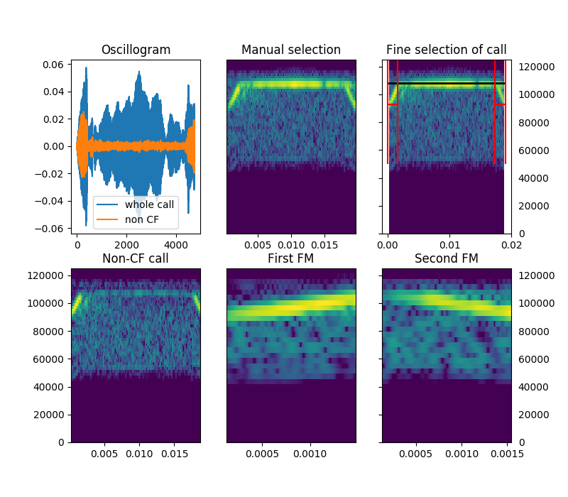

```
[[0, 294], [4664, 5209]]
[0, 294]
[4664, 5209]
```

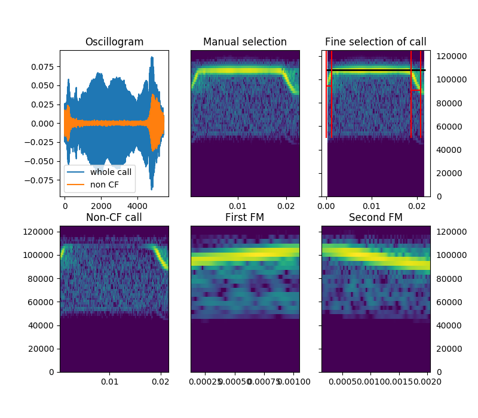

```
[[4285, 4615]]
[4285, 4615]
```

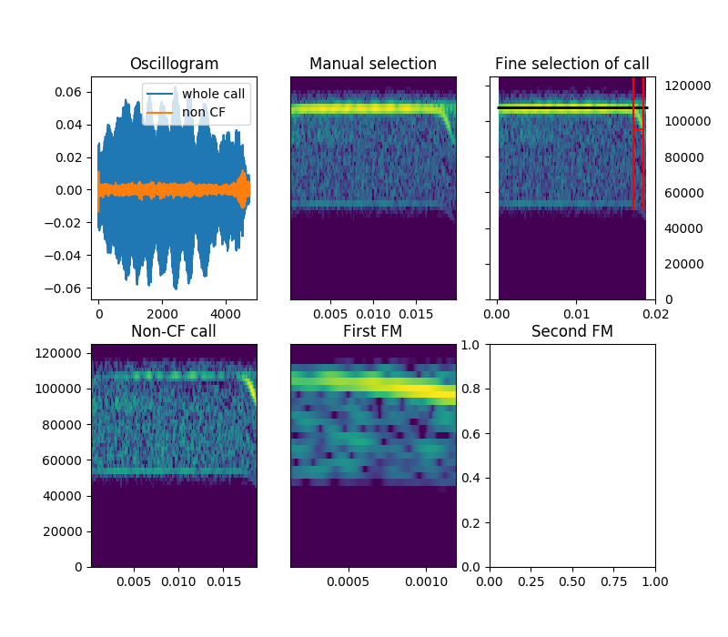

```
[[4804, 5223]]
[4804, 5223]
```

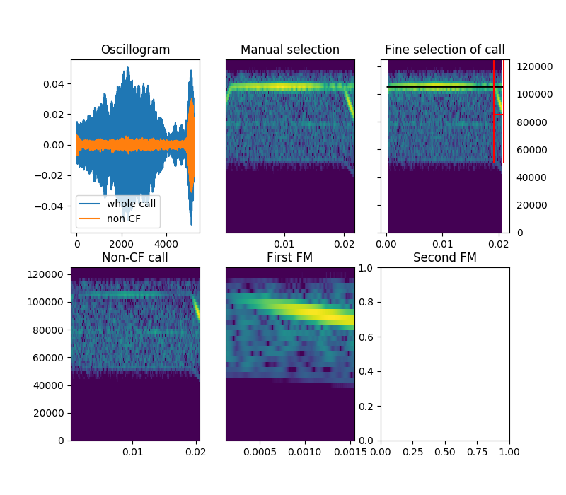

```
[[6307, 6647]]
[6307, 6647]
```

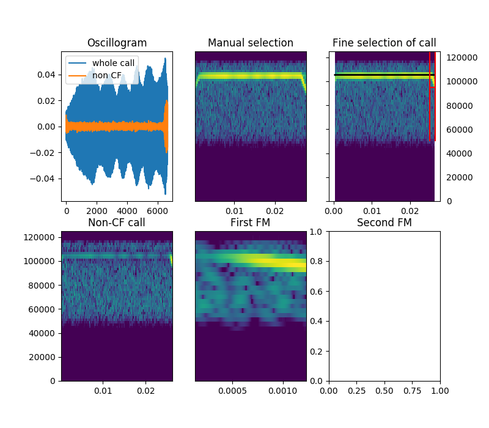

```
[[1784, 1789], [4023, 4481]]
[1784, 1789]
[4023, 4481]
```

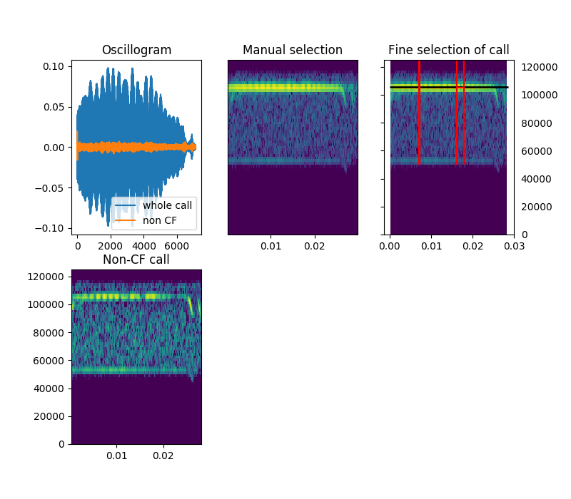

```
[[4247, 4747]]
[4247, 4747]
```

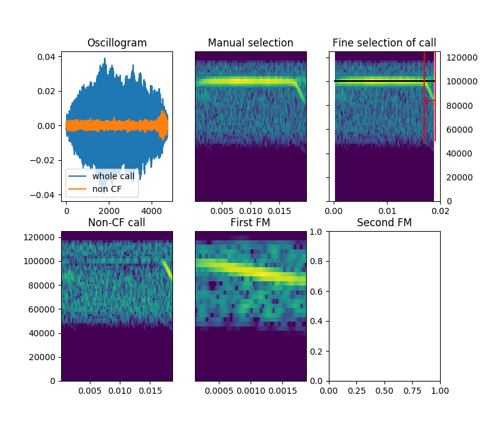

```
[[0, 331], [6118, 6409]]
[0, 331]
[6118, 6409]
```

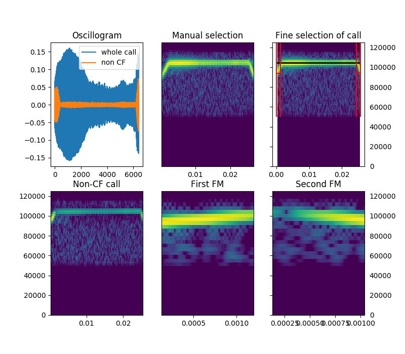

```
[[5361, 5696]]
[5361, 5696]
```

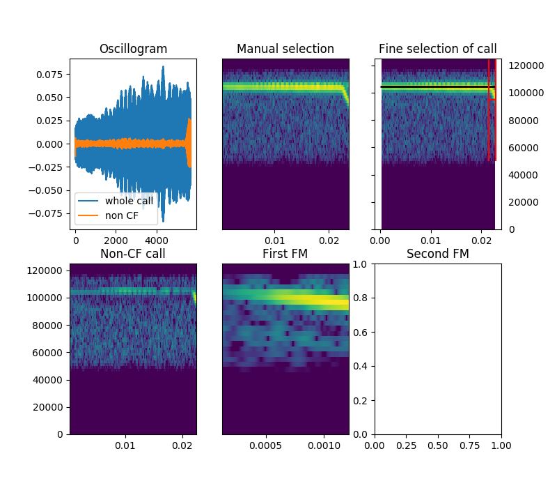

```
[[0, 280], [4552, 4984]]
[0, 280]
[4552, 4984]
```

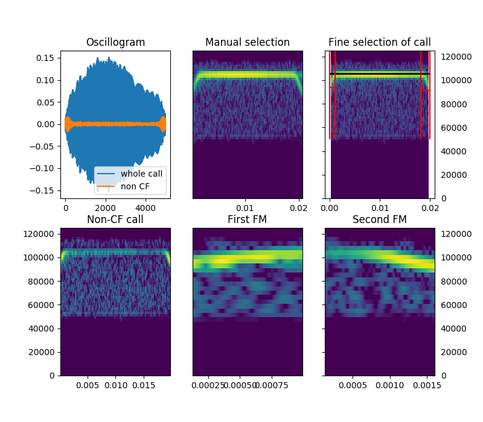

```
[[0, 489]]
[0, 489]
```

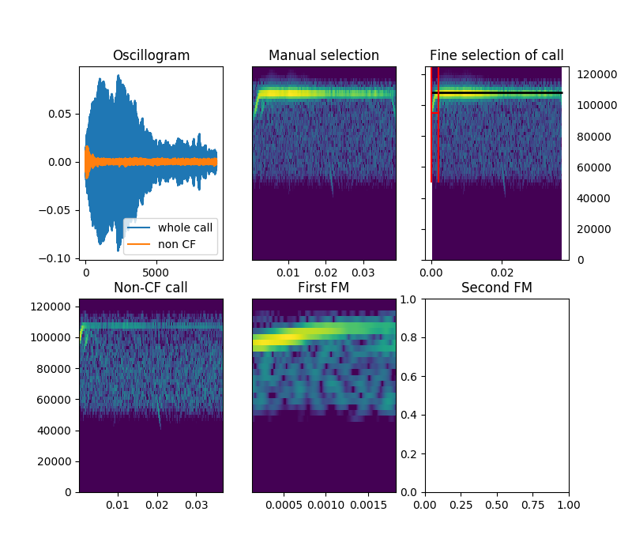

```
[ 250 4950 7508]
```

```python
b,a = signal.butter(8, np.array([55000.0, 115000])/(fs*0.5), 'bandpass')
all_msmts = []
for i in range(good_calls.shape[0]):
    each_row = good_calls.iloc[i,:]
    audio, fs = sf.read(anotation_audio_folder+each_row['audio_annotation_file']+'.WAV')
    bp_audio = signal.lfilter(b,a,audio[:,0])
    start_sample, end_sample = int(each_row['call_start_time']*fs), int(each_row['call_end_time']*fs)
    one_call = bp_audio[start_sample:end_sample]

    try:
        sounds, msmts = measure_hbc_call(one_call, fs=250000, min_cf_duration=0.01, q_factor=5, relative_threshold=0.3,
                                         fm_max_durn=0.007)
        msmts['annotation'] = each_row['audio_annotation_file']

        make_overview_figure(audio, sounds, msmts,fftsize=128, dyn_range=100)
        plt.savefig( 'overview_'+each_row['audio_annotation_file']+'.WAV'+'.png')
        all_msmts.append(msmts)
    except:
        pass
```

```python
msmts
```

|  | call_duration | call_energy | cf_energy | peak_frequency | upfm_end_time | upfm_energy | upfm_start_time | upfm_terminal_frequency | annotation |
| --- | --- | --- | --- | --- | --- | --- | --- | --- | --- |
| 0 | 0.037044 | 9.311363 | 9.27209 | 108398.4375 | 0.001956 | 0.023991 | 0.0 | 95092.02454 | matching_annotaudio_Aditya_2018-08-17_34_24 |

```python
pd.concat(all_msmts)
```

|  | annotation | call_duration | call_energy | cf_energy | downfm_end_time | downfm_energy | downfm_start_time | downfm_terminal_frequency | peak_frequency | upfm_end_time | upfm_energy | upfm_start_time | upfm_terminal_frequency |
| --- | --- | --- | --- | --- | --- | --- | --- | --- | --- | --- | --- | --- | --- |
| 0 | matching_annotaudio_Aditya_2018-08-17_34_2 | 0.018996 | 1.691036 | 1.602774 | 0.018988 | 0.022788 | 0.017316 | 92703.349282 | 108398.4375 | 0.001604 | 0.056714 | 0.0 | 92892.768080 |
| 0 | matching_annotaudio_Aditya_2018-08-17_34_3 | 0.021844 | 5.995145 | 5.711813 | 0.020836 | 0.207832 | 0.018656 | 90825.688073 | 108398.4375 | 0.001176 | 0.042427 | 0.0 | 94387.755102 |
| 0 | matching_annotaudio_Aditya_2018-08-17_34_4 | 0.018996 | 3.722234 | 3.702551 | 0.018460 | 0.008374 | 0.017140 | 95454.545455 | 107421.8750 | NaN | NaN | NaN | NaN |
| 0 | matching_annotaudio_Aditya_2018-08-17_34_7 | 0.020900 | 1.697387 | 1.614010 | 0.020892 | 0.073173 | 0.019216 | 85322.195704 | 105468.7500 | NaN | NaN | NaN | NaN |
| 0 | matching_annotaudio_Aditya_2018-08-17_34_12 | 0.026596 | 3.773499 | 3.739374 | 0.026588 | 0.023660 | 0.025228 | 94852.941176 | 105468.7500 | NaN | NaN | NaN | NaN |
| 0 | matching_annotaudio_Aditya_2018-08-17_34_19 | 0.018996 | 1.265326 | 1.254009 | 0.018988 | 0.005571 | 0.016988 | 84000.000000 | 100585.9375 | NaN | NaN | NaN | NaN |
| 0 | matching_annotaudio_Aditya_2018-08-17_34_20 | 0.025644 | 27.705693 | 27.086338 | 0.025636 | 0.249154 | 0.024472 | 94501.718213 | 104492.1875 | 0.001324 | 0.299886 | 0.0 | 93655.589124 |
| 0 | matching_annotaudio_Aditya_2018-08-17_34_21 | 0.022792 | 5.726977 | 5.665742 | 0.022784 | 0.045697 | 0.021444 | 94776.119403 | 104492.1875 | NaN | NaN | NaN | NaN |
| 0 | matching_annotaudio_Aditya_2018-08-17_34_22 | 0.019944 | 27.187350 | 27.135052 | 0.019936 | 0.023757 | 0.018208 | 91435.185185 | 105468.7500 | 0.001120 | 0.017066 | 0.0 | 93750.000000 |
| 0 | matching_annotaudio_Aditya_2018-08-17_34_24 | 0.037044 | 9.311363 | 9.272090 | NaN | NaN | NaN | NaN | 108398.4375 | 0.001956 | 0.023991 | 0.0 | 95092.024540 |

### Checking it all out to see how well a simulated example can be segmented (minimal noise, symmetric up and down FM parts)

```
[[626, 2249], [11752, 13257]]
[626, 2249]
[11752, 13257]
```

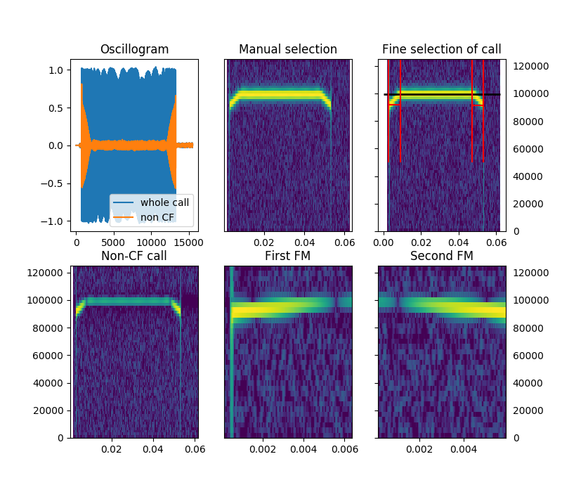

```python
one_call = np.concatenate((np.zeros(500),cfcall.copy(),np.zeros(500)))

sounds, msmts = measure_hbc_call(one_call, fs=250000, min_cf_duration=0.01, q_factor=5, relative_threshold=0.3,
                                 fm_max_durn=0.010, background_percentile=25)
msmts['annotation'] = each_row['audio_annotation_file']

make_overview_figure(audio, sounds, msmts,fftsize=128, dyn_range=100)
#plt.savefig( 'overview_'+each_row['audio_annotation_file']+'.WAV'+'.png')
#all_msmts.append(msmts)
```

```python
msmts
```

|  | call_duration | call_energy | cf_energy | downfm_end_time | downfm_energy | downfm_start_time | downfm_terminal_frequency | peak_frequency | upfm_end_time | upfm_energy | upfm_start_time | upfm_terminal_frequency | annotation |
| --- | --- | --- | --- | --- | --- | --- | --- | --- | --- | --- | --- | --- | --- |
| 0 | 0.061996 | 6251.839639 | 6092.949811 | 0.053028 | 75.131659 | 0.047008 | 91528.239203 | 99609.375 | 0.008996 | 75.048753 | 0.002504 | 91651.263093 | matching_annotaudio_Aditya_2018-08-17_34_32 |

```python
print('This report was last run at:', datetime.now())
```

```
('This report was last run at:', datetime.datetime(2020, 2, 9, 17, 39, 59, 15355))
```